# Lab 1: Intro to R

### Exercise 4

Years: 1940 - 2002 Dimensions of data frame: 63 observations (rows) x 3 variables (columns) Variable (column) names: year, boys, girls

```r
?present
```

```
## starting httpd help server ... done
```

```r
dim(present)
```

```
## [1] 63  3
```

### Exercise 5

The count within the present data frame, for the numbers of boys and girls born in the United States between 1940 and 2002, is of a *significantly* greater magnitude than the count within arbuthnot as highlighted by the comparison between minimum and maximum baptisms (for arbuthnot) and births (for present).

```r
arbuthnot %>%
  summarize(min = min(boys), max = max(boys))
```

```
##    min  max
## 1 2890 8426
```

```r
present %>%
  summarize(min=min(boys), max = max(boys))
```

```
##       min     max
## 1 1211684 2186274
```

### Exercise 6

Arbuthnot’s observation about boys being born in greater proportion than girls does hold up in the U.S.

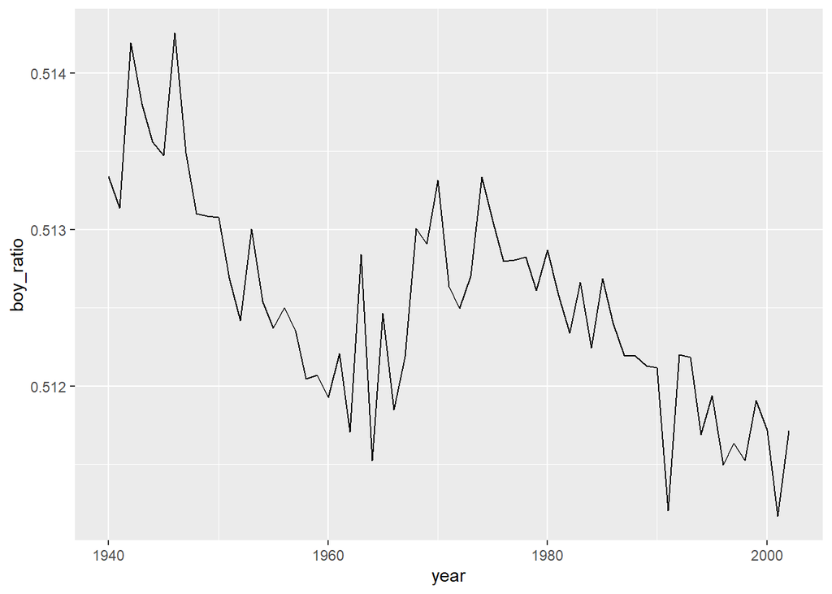

```r
present <- present %>%
  mutate(total = boys + girls)

present <- present %>%
  mutate(boy_ratio = boys / total)

ggplot(data = present, aes(x = year, y = boy_ratio)) +
  geom_line()
```

### Exercise 7

We saw the most total births in the US in 1961.

```r
present %>%
  arrange(desc(total))
```

```
##    year    boys   girls   total boy_ratio
## 1  1961 2186274 2082052 4268326 0.5122088
## 2  1960 2179708 2078142 4257850 0.5119269
## 3  1957 2179960 2074824 4254784 0.5123550
## 4  1959 2173638 2071158 4244796 0.5120713
## 5  1958 2152546 2051266 4203812 0.5120462
## 6  1962 2132466 2034896 4167362 0.5117064
## 7  1956 2133588 2029502 4163090 0.5125011
## 8  1990 2129495 2028717 4158212 0.5121179
## 9  1991 2101518 2009389 4110907 0.5112054
## 10 1963 2101632 1996388 4098020 0.5128408
## 11 1992 2082097 1982917 4065014 0.5121992
## 12 2000 2076969 1981845 4058814 0.5117182
## 13 1955 2073719 1973576 4047295 0.5123716
## 14 1989 2069490 1971468 4040958 0.5121286
```

[output cut: 49 more lines]